# corncob and DESeq2

Bryan D Martin

For this tutorial we will be comparing differential abundance hypothesis testing results from corncob and DESeq2. I will be using the data and following the tutorial from the DESeq2 tutorial available at [this webpage](https://joey711.github.io/phyloseq-extensions/DESeq2.html).

First, let’s load the required packages.

```r
library(corncob)
library(DESeq2)
library(phyloseq)
library(dplyr)
```

```r
sigtab[1:5,]
```

```
##            baseMean log2FoldChange     lfcSE      stat        pvalue
## taxon49    2.264433      -1.247421 0.3180791 -3.921733 0.00008791441
## taxon58    1.462675       3.260123 0.7537185  4.325385 0.00001522657
## taxon135   8.561293      -1.266032 0.3170883 -3.992679 0.00006533111
## taxon176 158.588600      -1.214061 0.2928066 -4.146289 0.00003379067
## taxon266   3.106247      -1.707317 0.4275008 -3.993715 0.00006504595
##                 padj  Kingdom         Phylum                 Class
## taxon49  0.019820704 Bacteria     Firmicutes            Clostridia
## taxon58  0.009440471 Bacteria Proteobacteria Epsilonproteobacteria
## taxon135 0.018002351 Bacteria     Firmicutes            Clostridia
## taxon176 0.014452019 Bacteria     Firmicutes            Clostridia
## taxon266 0.018002351 Bacteria  Bacteroidetes           Bacteroidia
##                      Order             Family            Genus
## taxon49      Clostridiales    Lachnospiraceae      Coprococcus
## taxon58  Campylobacterales Campylobacteraceae    Campylobacter
## taxon135     Clostridiales               <NA>             <NA>
## taxon176     Clostridiales    Ruminococcaceae Faecalibacterium
## taxon266     Bacteroidales      Rikenellaceae        Alistipes
##                       Species
## taxon49                  <NA>
## taxon58  Campylobacter rectus
## taxon135                 <NA>
## taxon176                 <NA>
## taxon266                 <NA>
```

We can see the 13 taxa in which DESeq2 identified differential abundance by examining the row names of `sigtab`.

```r
rownames(sigtab)
```

```
##  [1] "taxon49"   "taxon58"   "taxon135"  "taxon176"  "taxon266"
##  [6] "taxon882"  "taxon959"  "taxon1886" "taxon1918" "taxon2008"
## [11] "taxon2046" "taxon2110" "taxon2315"
```

Now we will test the same hypothesis using `corncob`. This framework allows us to control for the effect of diagnosis metadata on the variance of the relative abundances. The details of the syntax of the `corncob` functions are explained in other tutorials, so for the purposes of this tutorial I will just run the code.

```r
corn_output <- differentialTest(formula = ~ DIAGNOSIS,
                                phi.formula = ~ DIAGNOSIS,
                                formula_null = ~ 1,
                                phi.formula_null = ~ DIAGNOSIS,
                                test = "Wald", boot = FALSE,
                                data = kostic,
                                fdr_cutoff = 0.05)
```

We can print out the significant taxa using:

```r
corn_output$significant_taxa
```

```
##  [1] "taxon49"   "taxon135"  "taxon176"  "taxon264"  "taxon266"
##  [6] "taxon277"  "taxon433"  "taxon516"  "taxon626"  "taxon800"
## [11] "taxon882"  "taxon1145" "taxon1212" "taxon1697" "taxon1734"
## [16] "taxon1886" "taxon1926" "taxon1975" "taxon2008" "taxon2029"
## [21] "taxon2046" "taxon2228" "taxon2251" "taxon2263" "taxon2385"
## [26] "taxon2505"
```

Alternatively, we can display this information graphically with estimates and confidence intervals using `plot`. We will trim the taxonomic labels so the plot does not become too cluttered:

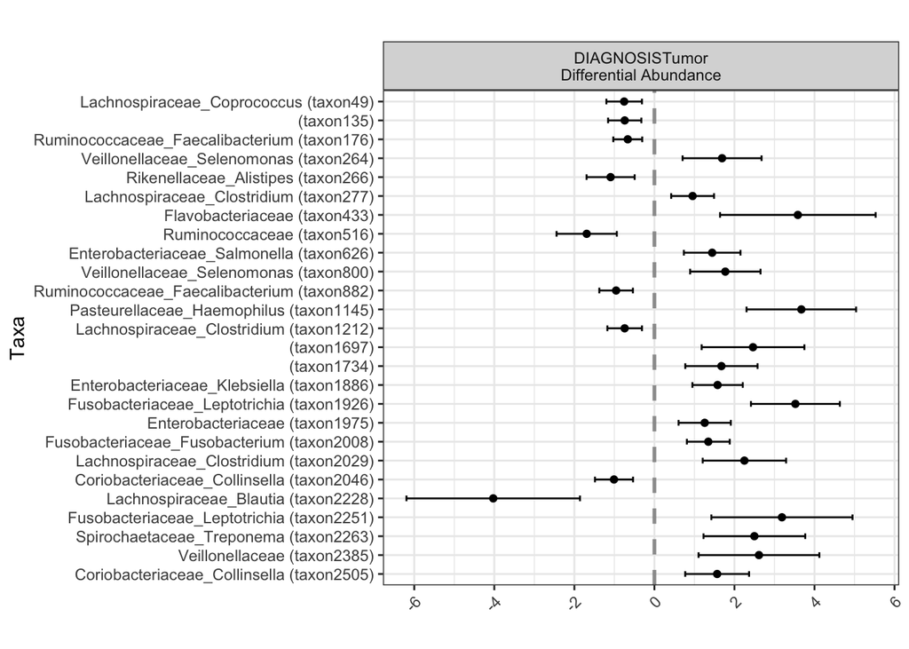

```r
plot(corn_output, level = c("Family", "Genus"))
```

Now, we will examine some of the taxa for which the qualitative results from `corncob` and `DESeq2` differ. Let’s examine the taxa that `DESeq2` finds significance and `corncob` does not first.

```r
# Store the significant OTU names as objects
ds2_signif <- rownames(sigtab)
corn_signif <- corn_output$significant_taxa

# Get names in ds2_signif that are not in corn_signif
setdiff(ds2_signif, corn_signif)
```

```
## [1] "taxon58"   "taxon959"  "taxon1918" "taxon2110" "taxon2315"
```

Let’s examine the first, OTU58. First, we will fit the model for this OTU individually, then we will plot it.

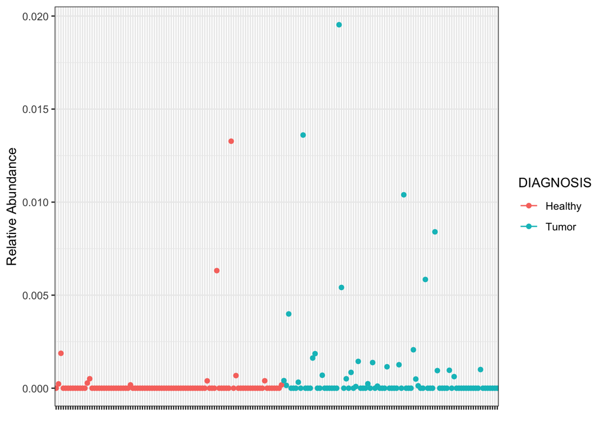

```r
mod58 <- bbdml(formula = taxon58 ~ DIAGNOSIS,
               phi.formula = ~ DIAGNOSIS,
               data = kostic)
plot(mod58, color = "DIAGNOSIS", B=0) + ggplot2::theme(axis.text.x = ggplot2::element_blank())
```

Next, we will examine the taxa that `corncob` finds significance and `DESeq2` does not. We will fit and plot the model in the same way.

```r
# Get names in corn_signif that are not in ds2_signif
setdiff(corn_signif, ds2_signif)
```

```
##  [1] "taxon264"  "taxon277"  "taxon433"  "taxon516"  "taxon626"
##  [6] "taxon800"  "taxon1145" "taxon1212" "taxon1697" "taxon1734"
## [11] "taxon1926" "taxon1975" "taxon2029" "taxon2228" "taxon2251"
## [16] "taxon2263" "taxon2385" "taxon2505"
```

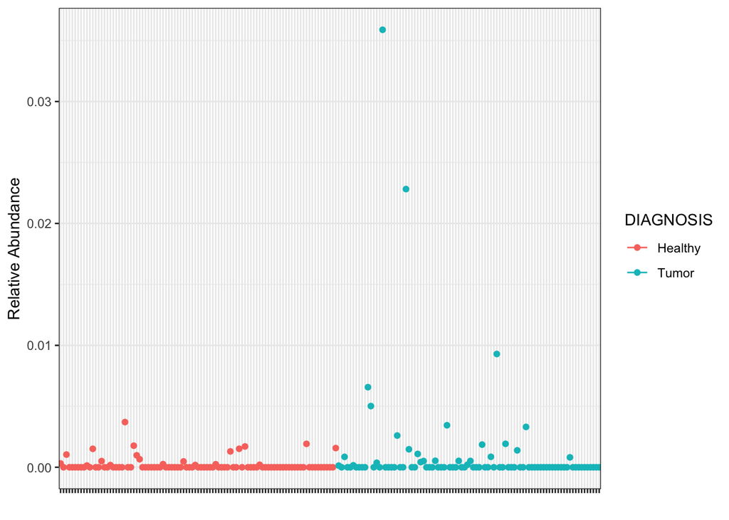

```r
mod264 <- bbdml(formula = taxon264 ~ DIAGNOSIS,
                phi.formula = ~ DIAGNOSIS,
                data = kostic)
plot(mod264, color = "DIAGNOSIS", B=0) + ggplot2::theme(axis.text.x = ggplot2::element_blank())
```

Unfortunately, because this is real data, there is no way to know the ``truth’’ about whether this taxon is truly differentially abundant or not. You can examine these plot, or generate similar plots from the other non-overlapping taxa, and decide whether you think a model should have identified differential abundance or not.